# Veštačke neuronske mreže u Juliji

Posmatra se neuronska mreža sa propagacijom signala unapred. Mreža je podeljena u slojeve neurona, gde svaki sloj sadrži niz neurona sa istom aktivacionom funkcijom. Tipične akvitacione funkcije su: linearna, sigmoidna, tangensni sigmoid, ReLU, itd.

Stoga će se na početku definisati takve funkcije i njihovi izvodi.

```julia
# Neke aktivacione funkcije i njihovi izvodi ...
sigmoid(Z) = 1 ./ (1 .+ exp.(-Z))
izvodSigmoid(O) = (O .* (1 .- O))

linear(Z) = Z
izvodLinear(O) = 1.0

tansig(Z) = tanh.(Z)
izvodTansig(O) = 0.5(1 .- O.*O);
```

Ovde je ulaz u aktivacionu funkciju vektor *Z*, dok se vrednosti izvoda aktivacione funkcije računaju na osnovu izlaza neurona *O*, radi bržeg izračunavanja. (U primeni, vrednost izlaza aktivacione funkcije se kešira i kasnije se koristi za računanje njenog izvoda.)

Nadalje, uvodi se struktura podataka da bi se opisao jedan sloj neurona.

```julia
mutable struct SlojNeurona
    W   # težine neurona
    b   # pragovi neurona
    aktivacionaFja
    izvodAktivacioneFje
    O   # izlazi sloja
    X   # ulazi u sloj
    dW  # promena težina
    db  # promena pragova
    vW  # inercija težina (kada se koristi momentum)
    vb  # inercija pragova (kada se koristi momentum)

    SlojNeurona(W, b, aktivacionaFja, izvodAktivacioneFje, O, X, dW, db, vW, vb) = new(W, b, aktivacionaFja, izvodAktivacioneFje, O, X, dW, db, vW, vb)
end
```

Polja uvedene strukture sadrže parametre mreže *W* i *b* koji će se kasnije podešavati njenom obukom. Pored toga, svaki sloj može imati drugačiju aktivacionu funkciju, te se ona i funkcija njenog izvoda takođe memorišu u strukturi. Algoritam za podešavanje parametera mreže će formirati korekcije parametara *dW* i *db*, dok su *vW* i *vb* pomoćne vrednosti gde se pamte inercijalne vrednosti za verziju algoritma sa momentum faktorom. Vektori ulaza u sloj *X* i izlaza iz njega *Y* se takođe memorišu kako bi realizacija koda bila jednostavnija (očiglednija). Treba primetiti da su izlazi jednog skrivenog sloja ujedno ulazi u naredni sloj, tako da se na iste vrednosti referiše iz susednih slojeva. Kako se ovde memorišu pokazivači na nizove, memorijsko zauzeće je beznačajno.

Inicijalizacija sloja neurona zahteva da se postavi broj neurona u sloju *brojIzlaza* i broj ulaza u sloj *brojUlaza* kako bi se inicijalizovali parametri sloja (mreže). Početne vrednosti sinapsi *W* se postavljaju na slučajne vrednosti, dok se početne vrednosti pragova *b* postavljaju na nule.

```julia
function SlojNeurona(brojUlaza::Int, brojIzlaza::Int, fja=linear, fjaIzvoda=izvodLinear)
    W = randn(brojIzlaza, brojUlaza)
    z = zeros(brojIzlaza, 1)
    X = zeros(brojUlaza, 1)
    return SlojNeurona(W, z, fja, fjaIzvoda, z, X, W, z, W*0, z)
end;
```

Računanje izlaza sloja neurona se sprovodi na osnovu ulaza u sloj *X* i na osnovu interno memorisanih parametara *W* i *b*. Pri tome se računa vrednost aktivacije *Z* (ulaz u aktivacionu finkciju), kao i izlaz iz sloja *O*. Te obe vrednosti se memorišu u sloju.

```julia
function izlaz(sloj::SlojNeurona, X)
    sloj.X = X
    Z = sloj.W * X .+ sloj.b
    O = sloj.aktivacionaFja(Z)
    sloj.O = O
    return O
end;
```

Ovde treba primetiti da je za računanje primenjana vektorizacija podataka, tj. jednim pozivom funkcije *izlaz* se izračunaju odzivi sloja neurona za sve elemente obučavajućeg skupa.

Struktura *NeuronskaMreža* modeluje celu neuronsku mrežu preko uređene kolekcije slojeva neurona. Stoga je jedino polje strukture kontejner slojeva nazvan *slojevi*.

```julia
struct NeuronskaMreža
    slojevi
    NeuronskaMreža(slojevi) = new(slojevi)
end;
```

Računanje izlaza mreže se dobija pozivom funkcije čiji su parametri: *NeuronskaMreža* čiji se odziv računa i ulazi u mrežu *X*. Kao i kod računanja izlaza sloja neurona, i ovde se više vektora ulaza može postaviti (po kolonama) u matricu *X*.

```julia
function izlaz(mreza::NeuronskaMreža, X)
    O = X
    for sloj in mreza.slojevi
        O = izlaz(sloj, O)
    end
    return O
end;
```

Na osnovu izračunatih izlaza iz mreže i željenih (zadatih) izlaza *fjaCilja* računa ukupnu grešku, koja se minimizuje u procesu obuke neuronske mreže. Sam postupak obuke, zasnovan na *Back propagation* algoritmu (BP algoritam), iterativno ažurira vrednosti parametara mreže upotrebom izvoda (gradijenta) funkcije cilja po parametrima mreže.

```julia
using Statistics

fjaCilja(Ymreza, Yzadato) = 0.5 * mean((Ymreza .- Yzadato).^2)

izvodFjeCilja(Ymreza, Yzadato) = Ymreza .- Yzadato;
```

Kako se radi o izvodu složene funkcije, koriste se parcijalni izvodi funkcije cilja, izvodi aktivacionih funkcija (opisan funkcijom *izvodFjeCilja*) i ostali izvodi na osnovu kojih se računaju pomenuti gradijenti.

```julia
function gradijenti(sloj::SlojNeurona, dO)
    dZ = sloj.izvodAktivacioneFje(sloj.O) .* dO
    sloj.dW = dZ * (sloj.X')
    sloj.db = sum(dZ, dims=2)
    dO = (sloj.W') * dZ
    return dO
end;
```

Iterativno ažuriranje vrednosti parametara (*W* i *b*) se vrši na osnovu gradijenata *dw* i *db* izračunatih funkcijom *gradijenti*.

```julia
function azurirajParametre(sloj::SlojNeurona, η, γ)
    if γ == 0.0
        sloj.W -= η * sloj.dW
        sloj.b -= η * sloj.db
    else
        sloj.vW = γ * sloj.vW .+ η * sloj.dW
        sloj.W -= sloj.vW

        sloj.vb = γ * sloj.vb .+ η * sloj.db
        sloj.b -= sloj.vb
    end
end;
```

Celokupan proces obuke neuronske mreže je opisan funkcijom *obuka* čiji su parametri:

- *mreza* - promenljiva mreža, koja se obučava,
- *Xzeljeni*, *Yzeljeni* - obučavajući skup sačinjen od parova ulaza i izlaza,
- *η* - parametar BP algoritma - koeficijent brzine obučavanja,
- *γ* - parametar BP algoritma - momentum faktor,
- *epsJ* - granična (mala) vrednost funkcije cilja J kada se obuka završava,
- *maxEpoha* - maksimalan broj epoha obuke (i tada se obuka prekida, ali željena funkcija cilja nije dostignuta),
- *prikazEpoha* - broj epoha nakon kojih se pojavljuje kontrolni ispis.

```julia
function obuka(mreza::NeuronskaMreža, Xzeljeni, Yzeljeni, η, γ=0.0, epsJ=1e-6, maxEpoha=10000, prikazEpoha=1000)
    η /= size(Yzeljeni, 2)              # normalizacija momentum faktora
    Jovi = []                           # kontejner J vrednosti tokom obuke

    for i = 1:maxEpoha
        Y = izlaz(mreza, Xzeljeni)              # odziv mreže
        J = fjaCilja(Y, Yzeljeni)
        if J < epsJ
            push!(Jovi, J)
            break                               # mreža je obučena
        end

        dO = izvodFjeCilja(Y, Yzeljeni)         # računanje gradijenata
        for sloj in reverse(mreza.slojevi)      # ... unazad
            dO = gradijenti(sloj, dO)
        end
        for sloj in reverse(mreza.slojevi)      # ažuriranje parametara mreže
            azurirajParametre(sloj, η, γ)
        end

        if rem(i, prikazEpoha) == 0             # kontrolni ispis
            println("it: ", i, " J:", J)
        end
        push!(Jovi, J)
    end
    return Jovi
end;
```

Podela obučavajućeg skupa na nekoliko podskupova nije implementirana u funkciji *obuka*, već se ostavlja čitaocu da to doda u svojoj implementacijij.

## Testni primeri

Paketi koji se upotrebljavaju u primerima su *Random* i *Plots*.

```julia
using Random, Plots
```

### Primer 1

Obučava se jednostavna neuronska mreža da "nauči" XOR funkciju dve promenljive. Stoga mreža ima 2 ulaza, 2 neurona u skrivenom sloju i jedan izlaz. Obuka se vrši BP - gradijentnim postupkom, gde je koeficijent brzine obučavanja 0.3.

```julia
Random.seed!(1234);
s1 = SlojNeurona(2, 2, sigmoid, izvodSigmoid)
s2 = SlojNeurona(2, 1)
mreza = NeuronskaMreža( (s1, s2) );
```

Obučavajući skup čine 4 para ulaza *X* i izlaza *Y*.

```julia
X = [0. 0. 1. 1.
     0. 1. 0. 1.]
Y = [0. 1. 1. 0.];
```

Definisana mreža se obučava pozivom funkcije *obuka*.

```julia
Js = obuka(mreza, X, Y, 0.3, 0.0, 0.001);
```

```
it: 1000 J:0.0025385411309763704
```

Obuka je zahtevala *n* epoha i postignuta je *J* vrednost funkcije cilja.

```julia
@show(n = length(Js), J = Js[end]);
```

```
n = length(Js) = 1050
J = Js[end] = 0.0009881584561632572
```

Obučena mreža za ulaze *X* na izlazu ima:

```julia
izlaz(mreza, X)
```

```
1×4 Array{Float64,2}:
 0.0576609  0.957571  0.958733  0.0328228
```

### Primer 2

U ovom primeru je BP algoritam iz prethodnog primera proširen inercijalnim članom. Koeficijent brzine obučavanja je postavljen na 0.1, a momentum faktor je postavljen na 0.9.

```julia
Random.seed!(1234);
s1 = SlojNeurona(2, 2, sigmoid, izvodSigmoid)
s2 = SlojNeurona(2, 1)
mreza = NeuronskaMreža( (s1, s2) )
X = [0. 0. 1. 1.
     0. 1. 0. 1.]
Y = [0. 1. 1. 0.]
Js = obuka(mreza, X, Y, 0.1, 0.9, 0.001);
```

Sada je obuka zahtevala *n* epoha i postignuta je *J* vrednost funkcije cilja.

```julia
@show(n = length(Js), J = Js[end]);
```

```
n = length(Js) = 300
J = Js[end] = 0.0009467320686533466
```

### Primer 3

Za razne inicijalne vrednosti parametara mreže *W* i *b* se posmatra trajanje obuke.

```julia
Random.seed!(1234);
rez = []
for test = 1:10
    s1 = SlojNeurona(2, 2, sigmoid, izvodSigmoid)
    s2 = SlojNeurona(2, 1)
    mreza = NeuronskaMreža( (s1, s2) )
    X = [0. 0. 1. 1.
         0. 1. 0. 1.]
    Y = [0. 1. 1. 0.]
    Js = obuka(mreza, X, Y, 0.3, 0.0, 1e-6, 10000, 10001)
    push!(rez, Js[3:end])
end;
```

Iz prikazanog dijagrama se može uočiti da trajanja obuke variraju...

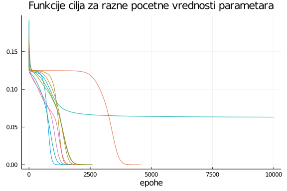

```julia
plot(rez, title = "Funkcije cilja za razne pocetne vrednosti parametara", lab ="", xlabel="epohe")
```

### Primer 4

Za nekoliko vrednosti koeficijenta brzine obučavanja se dobijaju različita trajanja obuke.

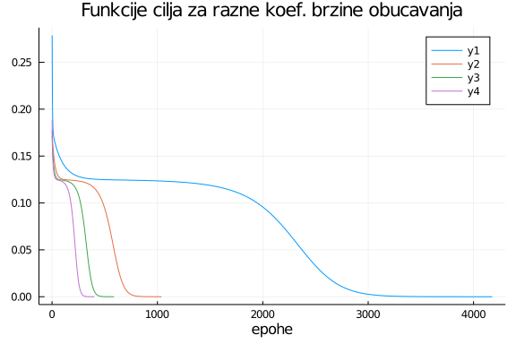

```julia
rez = []
for eta = 0.1:0.3:1.0
    Random.seed!(1234);
    s1 = SlojNeurona(2, 2, sigmoid, izvodSigmoid)
    s2 = SlojNeurona(2, 1)
    mreza = NeuronskaMreža( (s1, s2) )
    X = [0. 0. 1. 1.
         0. 1. 0. 1.]
    Y = [0. 1. 1. 0.]
    Js = obuka(mreza, X, Y, eta, 0.0, 1e-6, 10000, 10001)
    push!(rez, Js[3:end])
end
plot(rez, title = "Funkcije cilja za razne koef. brzine obucavanja", xlabel="epohe")
```

Obučavanja su ponovljena, ali sada za različite vrednosti momentum faktora.

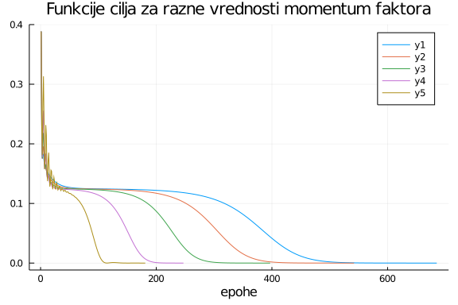

```julia
rez = []
for gama = 0.5:0.1:0.9
    Random.seed!(1234);
    s1 = SlojNeurona(2, 2, sigmoid, izvodSigmoid)
    s2 = SlojNeurona(2, 1)
    mreza = NeuronskaMreža( (s1, s2) )
    X = [0. 0. 1. 1.
         0. 1. 0. 1.]
    Y = [0. 1. 1. 0.]
    Js = obuka(mreza, X, Y, 0.3, gama, 1e-6, 10000, 10001)
    push!(rez, Js)
end
plot(rez, title = "Funkcije cilja za razne vrednosti momentum faktora", xlabel="epohe")
```

### Primer 5

Sada se posmatra uticaj veličine mreže na brzinu njene obuke. Menjan je broj neurona u skrivenom sloju.

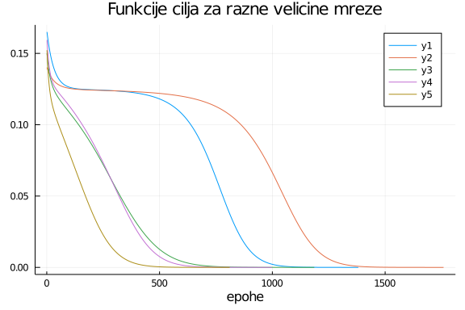

```julia
Random.seed!(1234);
rez = []
for brojNeurona = 2:2:10
    s1 = SlojNeurona(2, brojNeurona, sigmoid, izvodSigmoid)
    s2 = SlojNeurona(brojNeurona, 1)
    mreza = NeuronskaMreža( (s1, s2) )
    X = [0. 0. 1. 1.
         0. 1. 0. 1.]
    Y = [0. 1. 1. 0.]
    Js = obuka(mreza, X, Y, 0.3, 0.0, 1e-6, 10000, 10001)
    push!(rez, Js[10:end])
end
plot(rez, title = "Funkcije cilja za razne velicine mreze", xlabel="epohe")
```

### Primer 6

Trenira se neuronska mreža da nauči funkciju *sin(x)/x* na intervalu [-10, 10]. Radi se o neuronskoj mreži sa jednim ulazom, dva skrivena sloja sa 20 i 5 neurona i jednim izlazom.

```julia
xl = collect(-10:0.1:-0.1)
xd = collect(0.1:0.1:10)
X = [xl; 0.; xd]'
Y = [sin.(xl) ./ xl; 1.; sin.(xd) ./ xd]'

Random.seed!(1234);

s1 = SlojNeurona(1, 20, sigmoid, izvodSigmoid)
s2 = SlojNeurona(20, 5, sigmoid, izvodSigmoid)
s3 = SlojNeurona(5, 1)
mreza = NeuronskaMreža( (s1, s2, s3) )

Js = obuka(mreza, X, Y, 0.1, 0.8, 1e-5, 100000, 10000);
```

```
it: 10000 J:0.0034675782570465184
it: 20000 J:0.0012891746527339146
it: 30000 J:0.000871461265643754
it: 40000 J:0.0005034428745670476
it: 50000 J:0.000232604277410455
it: 60000 J:8.295226267898459e-5
it: 70000 J:3.8494291758824803e-5
it: 80000 J:2.310264828982172e-5
it: 90000 J:1.6982123886873597e-5
it: 100000 J:1.3991638702605662e-5
```

Dijagram promene vrednosti funkcije cilja je (kada se "preskoči" prvih 1000 epoha):

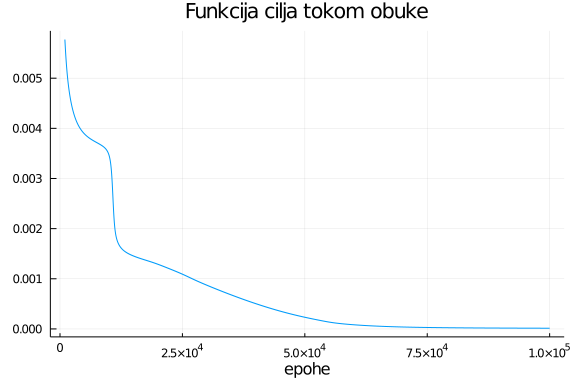

```julia
plot(1000:length(Js), Js[1000:end], title = "Funkcija cilja tokom obuke", lab="", xlabel="epohe")
```

Poklapanje dijagrama originalne funkcije i mapiranja koje je naučila mreža je:

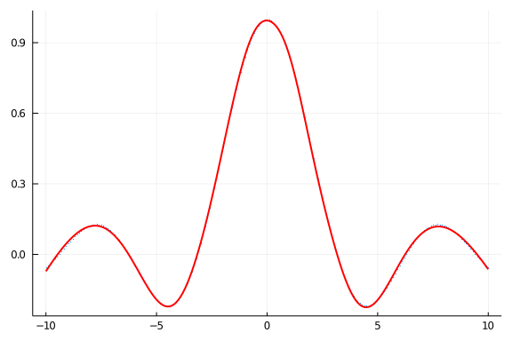

```julia
plot(X',Y',marker=1, lw=:0, lab="")
plot!(X',izlaz(mreza,X)',linecolor=:red,lw=2,lab="")
```

## Ponovljeni primeri sa aktivacionom funkcijom tangensnog sigmoida

Do sada se u svim primerima upotrebljavala sigmoid aktivaciona funkcija. Nadalje će ti primeri biti ponovljeni, ali je u svima upotrebljena aktivaciona funkcija tangenskog sigmoida. Za razliku od sigmoid funkcije gde su izlazi u intevalu (0, 1), tangensni sigmoid ima vrednosti u intervalu (-1, 1).

### Obučavanje XOR funkcije

Obučavajući skup za XOR funkciju je prilagođen tangensnom sigmoidu, te se neistina predstavlja sa -1, a istina sa 1.

```julia
X = [-1.0 -1.0  1.0  1.0
     -1.0  1.0 -1.0  1.0]
Y = [-1.0  1.0  1.0 -1.0];
```

Jedine razlike u odnosu na prethodni kod su u deklarisanju slojeva neurona gde se sada upotrebljavaju funkcije *tansig* i *izvodTansig*.

```julia
Random.seed!(1234);
s1 = SlojNeurona(2, 2, tansig, izvodTansig)
s2 = SlojNeurona(2, 1)
mreza = NeuronskaMreža( (s1, s2) );
Js = obuka(mreza, X, Y, 0.3, 0.0, 0.001);
```

Obuka je zahtevala *n* epoha i postignuta je *J* vrednost funkcije cilja,

```julia
@show(n = length(Js), J = Js[end]);
```

```
n = length(Js) = 97
J = Js[end] = 0.0009097749998584386
```

što je brže u odnosu na ranije primere.

Nadalje, dodaje se inercijalni član. Koeficijent brzine obučavanja je postavljen na 0.1, a momentum faktor je postavljen na 0.9.

```julia
Random.seed!(1234);
s1 = SlojNeurona(2, 2, tansig, izvodTansig)
s2 = SlojNeurona(2, 1)
mreza = NeuronskaMreža( (s1, s2) )
Js = obuka(mreza, X, Y, 0.1, 0.9, 0.001);
@show(n = length(Js), J = Js[end]);
```

```
n = length(Js) = 89
J = Js[end] = 0.0005984287530384578
```

U narednim dijagramima nisu prikazane funkcije cilja za prve dve iteracije jer imaju velike vrednosti i loše utiču na skaliranje dijagrama.

Prvo se posmatra trajanje obuke za razne inicijalne vrednosti parametara mreže *W* i *b*.

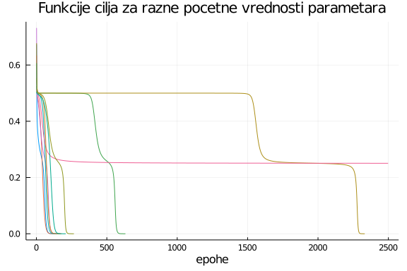

```julia
Random.seed!(1234);
rez = []
for test = 1:10
    s1 = SlojNeurona(2, 2, tansig, izvodTansig)
    s2 = SlojNeurona(2, 1)
    mreza = NeuronskaMreža( (s1, s2) )
    Js = obuka(mreza, X, Y, 0.3, 0.0, 1e-6, 2500, 2501)
    push!(rez, Js[3:end])
end;
plot(rez, title = "Funkcije cilja za razne pocetne vrednosti parametara", lab ="", xlabel="epohe")
```

Za nekoliko vrednosti koeficijenta brzine obučavanja se dobijaju različita trajanja obuke.

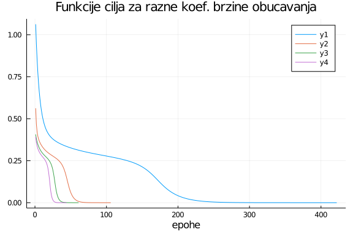

```julia
rez = []
for eta = 0.1:0.3:1.0
    Random.seed!(1234);
    s1 = SlojNeurona(2, 2, tansig, izvodTansig)
    s2 = SlojNeurona(2, 1)
    mreza = NeuronskaMreža( (s1, s2) )
    Js = obuka(mreza, X, Y, eta, 0.0, 1e-6, 10000, 10001)
    push!(rez, Js[3:end])
end
plot(rez, title = "Funkcije cilja za razne koef. brzine obucavanja", xlabel="epohe")
```

Obučavanja su ponovljena, ali sada za različite vrednosti momentum faktora.

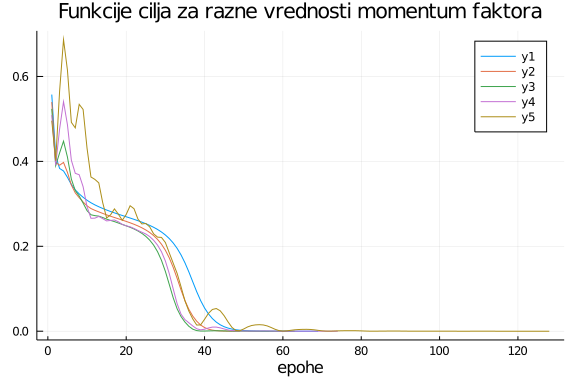

```julia
rez = []
for gama = 0.5:0.1:0.9
    Random.seed!(1234);
    s1 = SlojNeurona(2, 2, tansig, izvodTansig)
    s2 = SlojNeurona(2, 1)
    mreza = NeuronskaMreža( (s1, s2) )
    Js = obuka(mreza, X, Y, 0.3, gama, 1e-6, 300, 301)
    push!(rez, Js[3:end])
end
plot(rez, title = "Funkcije cilja za razne vrednosti momentum faktora", xlabel="epohe")
```

Sada se posmatra uticaj veličine mreže na brzinu njene obuke. Menjan je broj neurona u skrivenom sloju.

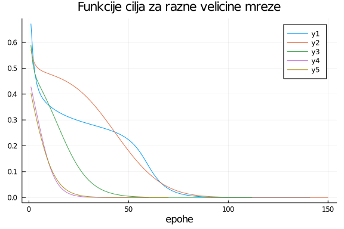

```julia
Random.seed!(1234);
rez = []
for brojNeurona = 2:2:10
    s1 = SlojNeurona(2, brojNeurona, tansig, izvodTansig)
    s2 = SlojNeurona(brojNeurona, 1)
    mreza = NeuronskaMreža( (s1, s2) )
    Js = obuka(mreza, X, Y, 0.3, 0.0, 1e-6, 10000, 10001)
    push!(rez, Js[3:end])
end
plot(rez, title = "Funkcije cilja za razne velicine mreze", xlabel="epohe")
```

### Primer sin(x)/x

Ponovo posmatramo primer *sin(x)/x*. Radi se o neuronskoj mreži sa jednim ulazom, dva skrivena sloja sa 20 i 5 neurona i jednim izlazom. Svi skriveni neuroni su sada sa tangensnim sigmoidima.

```julia
xl = collect(-10:0.1:-0.1)
xd = collect(0.1:0.1:10)
X = [xl; 0.; xd]'
Y = [sin.(xl) ./ xl; 1.; sin.(xd) ./ xd]'

Random.seed!(1234);

s1 = SlojNeurona(1, 20, tansig, izvodTansig)
s2 = SlojNeurona(20, 5, tansig, izvodTansig)
s3 = SlojNeurona(5, 1)
mreza = NeuronskaMreža( (s1, s2, s3) )

Js = obuka(mreza, X, Y, 0.1, 0.8, 1e-5, 100000, 10000);
```

```
it: 10000 J:0.0008922241135175673
it: 20000 J:0.0006545668329144039
it: 30000 J:0.00010855058330717522
it: 40000 J:1.6018366655297484e-5
```

Dijagram promene vrednosti funkcije cilja je (kada se "preskoči" prvih 1000 epoha):

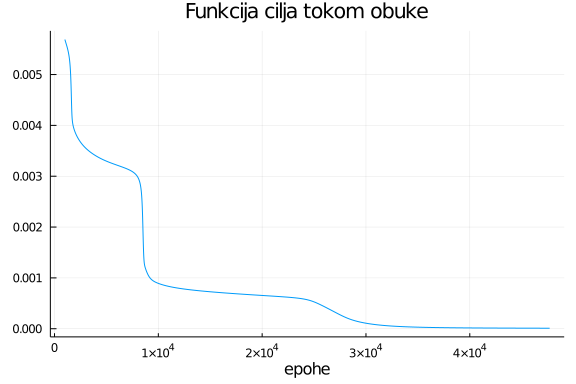

```julia
plot(1000:length(Js), Js[1000:end], title = "Funkcija cilja tokom obuke", lab="", xlabel="epohe")
```

I ova obuka se brže završila u odnosu sa slučaj kada je upotrebljen "običan sigmoid".

Published from Julija-VNM-2020.jmd using Weave.jl v0.10.6 on 2021-01-18.